# A 2021 COVID-19 Dataset by Michigan Counties: Reproducible Research Project

Delaney Fedewa

January 07, 2022

## Data

The Michigan COVID-19 data for this document were obtained at https://www.michigan.gov/coronavirus/0,9753,7-406-98163_98173---,00.html in the Public Use Datasets called "Cases by County and Date". The **December 29, 2021** dataset was used to create this report. Michigan county populations were found at https://worldpopulationreview.com/us-counties/states/mi which gives the 2018 census numbers. These were the most recent reliable numbers that I could find at the moment.

## Data munging

The Michigan COVID-19 dataset had a few peculiarities that needed to be dealt with in order to analyze it easily. There were several "counties" that are not actual Michigan counties that needed to be cleaned. The values for "Out-of-State" are not relevant for my purposes and were removed from the analyses. Likewise, prison populations ("FCI" and "MDOC") cannot be ascribed to particular counties and were, therefore, also removed. Cases with "Unknown" origins were also removed. Finally, the dataset lists "City of Detroit" as a separate entity, those numbers were added back into it's home country (Wayne) to facilitate analysis.

The number of cases and deaths per day are recorded for both confirmed and probable cases. To be as conservative as possible, these numbers were added together to create a total number of cases and deaths per day from each county (along with total cumulative cases and deaths). These total values, confirmed + probable, are used for all of the analyses in this report.

GIS information was left-joined onto the total data. The census data was also left-joined and used to create population-normalized values (cases or deaths per 100,000 population).

## Statewide Distribution Showing the Cases and Deaths of COVID-19

In Map A of Figure 1, the cases of COVID-19 in Michigan are shown. Within this map, counties are colored according to the number of confirmed positive cases of COVID-19 within them. The county with the highest number of confirmed positive cases in this map is Wayne County and Detroit City County combined.

In Map B of Figure 1, the deaths of COVID-19 in Michigan are shown. Within this map, counties are colored according to the number of deaths of COVID-19 within them. The county with the highest number of deaths in this map is Wayne County and Detroit City County combined.

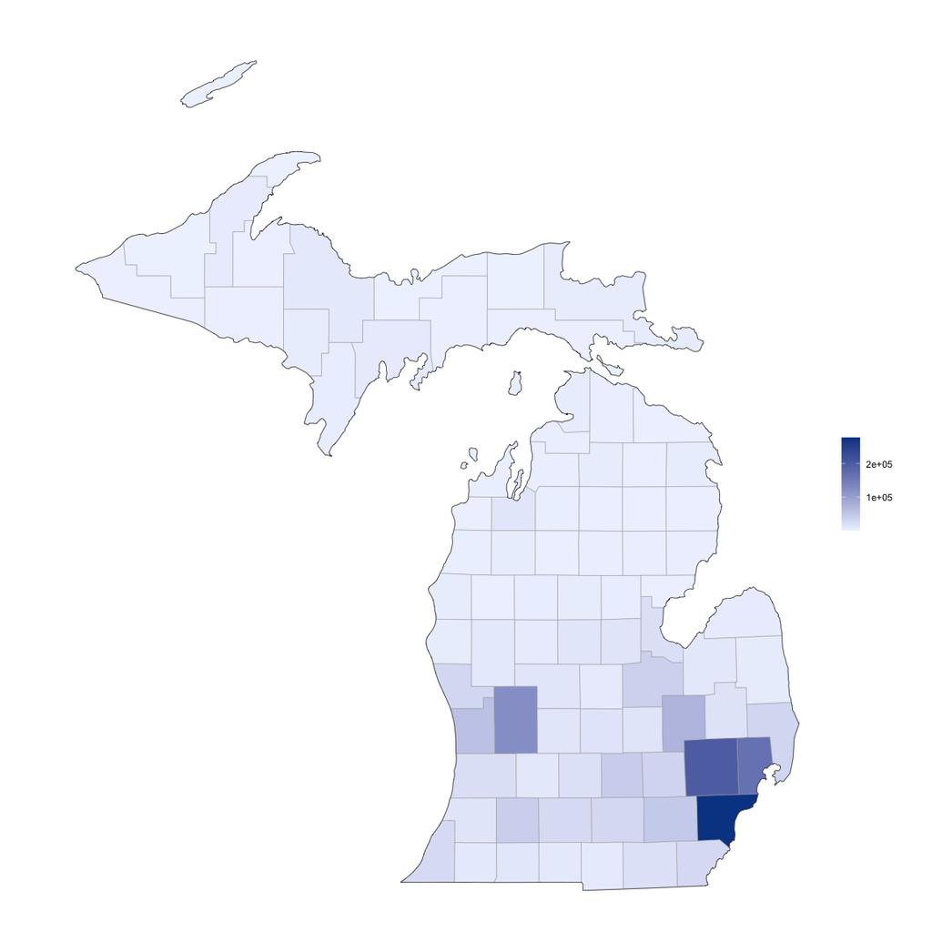

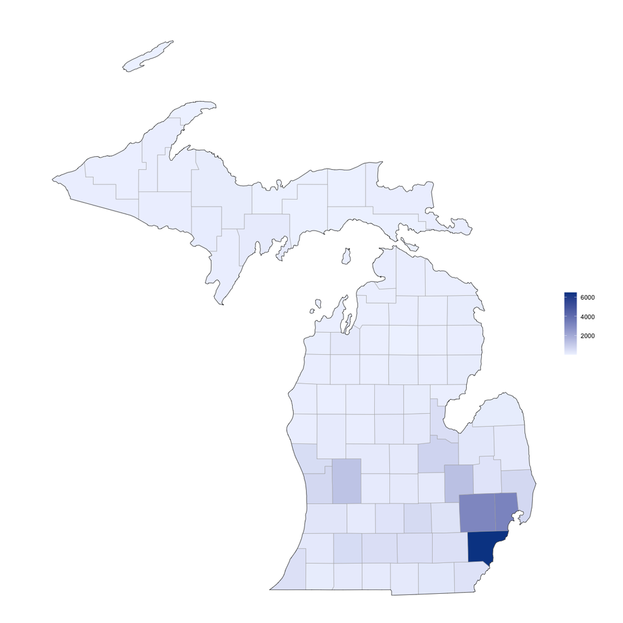

## State Overall Trends

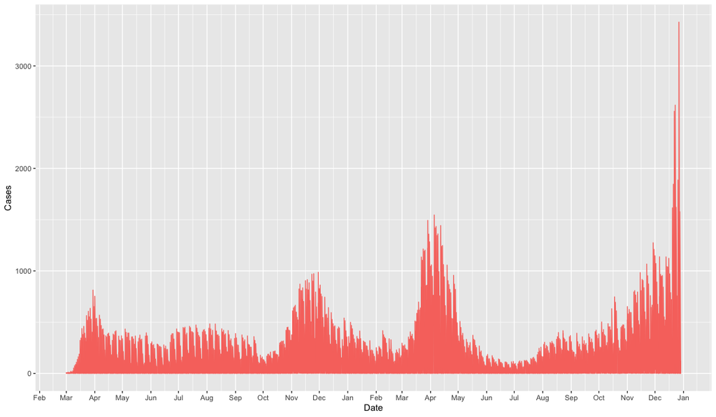

**Figure 2:** The amount of cases, monthly, throughout the entire state of Michigan from 2020 to 2021. The bars indicate the amount of cases.

## Comparing Counties

The three Michigan counties that are being compared are Clinton County, Mecosta County, and Gratiot County.

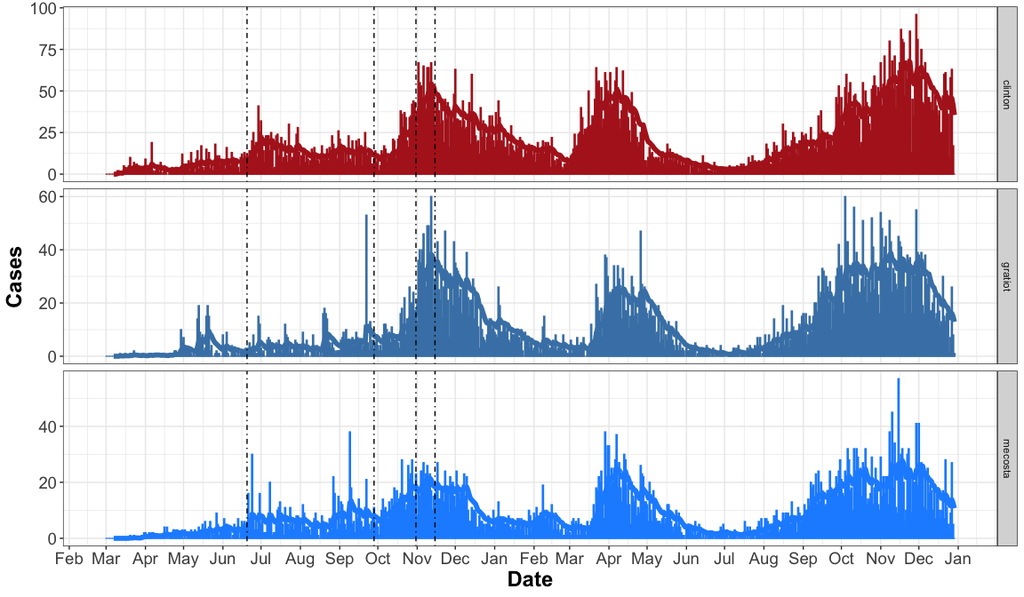

**Figure 3:** A comparison of the incidence of COVID-19 cases in Clinton County, Mecosta County, and Gratiot County by month from 2020 to 2021. The bars indicate the amount of cases.

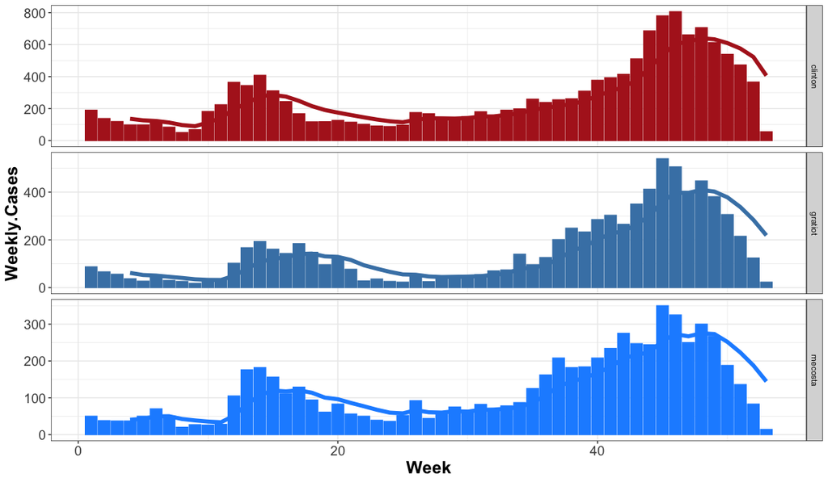

## Conclusions

Figure 3 shows the comparison of the incidence of COVID-19 in Clinton County, Mecosta County, and Gratiot County. It is clear to see how COVID-19 cases can vary from place to place. Although these are three different counties, they do have some similarities. The graphs show that the all three counties have a spike in cases in the months of November and December. But, they differ as well. For example, Clinton County has a great spike of cases between November and December of 2020; At the same date, Gratiot County also has a spike in cases and Mecosta County has almost half of the cases that Gratiot County has. The number of total cases in each of the three counties is compared in Figure 4, where it shows weekly cases. Between 0 and 10 weeks, cases remained below 100 for both Mecosta County and Gratiot County; but, Clinton County was slightly higher. The amount of weekly cases rose for all three counties between 10 and 20 weeks. Although throughout the four-week moving average the three graphs seem to look alike in format, they are not the same. Spikes where the bars exceed the line can be seen in one graph but not another. Random spikes can also be seen at different varying weeks. As it can be concluded: Clinton County has 14,986 cases of COVID-19, Mecosta County has 6,588 cases of COVID-19, and Gratiot County has 8,214 cases of COVID-19... Making Clinton County the county with the most cases of COVID-19 out of the three counties that were compared.

## References

Coronavirus disease (COVID-19) (2022). In World Health Organization. Retrieved from https://www.who.int/health-topics/coronavirus#tab=tab_1

Coronavirus - Michigan Data (2022). In Michigan.gov. Retrieved from https://www.michigan.gov/coronavirus/0,9753,7-406-98163_98173---,00.html

Population of Counties in Michigan (2021). In World Population Review. Retrieved from https://worldpopulationreview.com/us-counties/states/mi